# Diff-in-Diff and RD Class

## Regression discontinuity design

The packages we will need for the RD design are the following:

```r
library(tidyverse)  # For ggplot, %>%, and gang
library(broom)      # For converting models into tables
library(rdrobust)   # For robust nonparametric regression discontinuity
library(rddensity)  # For nonparametric regression discontinuity density tests
library(stargazer)  # For side-by-side tables
library(foreign)    # For reading dta databases
```

For this exercise, we will imagine the following situation: At the beginning of 6th grade, students take a test to determine if they can participate in an academically and intellectually gifted (AIG) program during middle school and high school. Acceptance is based on grades: Students who scored 75 or more are allowed to participate in the program. Students participating in the AIG program are given extra work and lessons. At the end of high school, students take a final test (with a maximum of 100 points) to measure how much they learned overall. The following hypothetical data is used to depict this exercise:

```r
# Load data
setwd("C:/Users/teres/OneDrive/Documents/Teaching/Econometrics course")
aig_program <- read_csv("aig_program.csv")
```

To do a RDD, we will develop the following steps:

### Step 1: Determine if process of assigning treatment is rule-based

There’s no test to determine if the process of assigning the treatment is rule-based. We will have to intuitively deduce it, based on the program’s implementation.

In this case, we can think that it is ruled-base.

### Step 2: Determine if the design is fuzzy or sharp

Since we know that the program was applied based on a rule, we want to next figure out how strictly the rule was applied. The threshold was 75 points on the test—did people who scored 73 slip into the AIG program, or did people who scored 80 not show up to the program?

We can see that no observation above the threshold is from the control group and viceversa by doing the following table:

```r
aig_program %>%
  group_by(aig, test_score >= 75) %>%
  summarize(count = n())
```

| aig | test_score >= 75 | count |
| --- | --- | --- |
| FALSE | FALSE | 346 |
| TRUE | TRUE | 654 |

### Step 3: Check for discontinuity in running variable around cutpoint

Next we need to see if there was any manipulation in the rating or running variable. We can suspect that lots of people have grades around 75 because of how the test was graded (i.e. teachers wanted to get students into the program so they bumped people up from 70 to 76).

We can check for this with a histogram of the running variable (test scores) and see if there are any big jumps around the threshold:

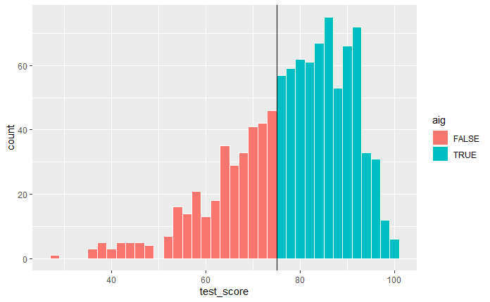

```r
ggplot(data = aig_program, mapping = aes(x = test_score, fill = aig)) +
  geom_histogram(binwidth = 2, color = "white") +
  geom_vline(xintercept = 75)
```

If there’s a jump, we want to check if it’s statistically significant. To test that, we can do a McCrary density test. This puts data into bins like a histogram, and then plots the averages and confidence intervals of those bins. If the confidence intervals of the density lines don’t overlap, then there’s likely something systematically wrong with how the test was scored (i.e. too many people getting 76 vs 74). If the confidence intervals overlap, there’s not any significant difference around the threshold and we’re fine.

```r
plotdensity <- rdplotdensity(rdd = rddensity(X = aig_program$test_score, c = 75),
                       X = aig_program$test_score)
```

[output not shown]

### Step 4: Check for discontinuity in outcome across running variable

We want to see if there’s a discontinuity in final scores based on participation in the AIG program.

To do this, we can plot the running variable on the x-axis, the outcome variable on the y-axis, and color the points by whether they participated in the program.

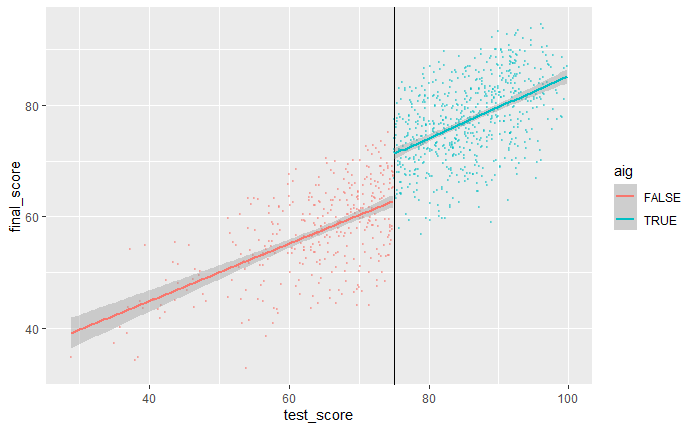

```r
ggplot(data = aig_program,
       mapping = aes(x = test_score, y = final_score, color = aig)) +
  geom_point(size = 0.5, alpha = 0.4) +
  geom_vline(xintercept = 75) +
  geom_smooth(method = "lm")
```

With this plot we can see there is a jump in scores after the thresholds. If we look at the confidence intervals of the graph, we can see that they do not overlap, which allows us to conclude that the program does have an effect in tests scores on students.

### Step 5: Measure the size of the effect

There’s a discontinuity, but how big is it? And is it statistically significant?

We can check the size two different ways: parametrically (i.e. using `lm()` with specific parameters and coefficients), and nonparametrically (i.e. not using `lm()` or any kind of straight line and instead drawing lines that fit the data more precisely). We will see only the parametric estimation in class.

**Parametric estimation**

First we’ll do it parametrically by using linear regression. Here we want to explain the variation in final scores based on the AIG test score and participation in the program:

$$\text{Final score} = \beta_0 + \beta_1 \text{AIG test score} + \beta_2 \text{AIG program} + \epsilon$$

To make it easier to interpret coefficients, we can center the test score column so that instead of showing the actual test score, it shows how many points above or below 75 the student scored.

```r
aig_program_centered <- aig_program %>%
  mutate(test_centered = test_score - 75)

model_1 <- lm(final_score ~ test_centered + aig, data = aig_program_centered)
summary(model_1)
```

```
Call:
lm(formula = final_score ~ test_centered + aig, data = aig_program_centered)

Residuals:
    Min      1Q  Median      3Q     Max
-19.915  -4.291   0.488   4.685  14.193

Coefficients:
              Estimate Std. Error t value Pr(>|t|)
(Intercept)   63.07472    0.46623  135.29   <2e-16 ***
test_centered  0.53471    0.02779   19.24   <2e-16 ***
aigTRUE        8.47011    0.74320   11.40   <2e-16 ***
---
Signif. codes:  0 ‘***’ 0.001 ‘**’ 0.01 ‘*’ 0.05 ‘.’ 0.1 ‘ ’ 1

Residual standard error: 6.518 on 997 degrees of freedom
Multiple R-squared:  0.7165,    Adjusted R-squared:  0.7159
F-statistic:  1260 on 2 and 997 DF,  p-value: < 2.2e-16
```

Here’s what these coefficients mean:

- $\beta_0$: This is the intercept. This is the test score for someone in the control group and who scored 74.9 on their initial test, on average will get 63.07 points on their final grade.
- $\beta_1$: This is the coefficient for `test_score_centered`. Every point you move up along the threshold,your grade moves by 0.53 points.
- $\beta_2$: This is the coefficient for AIG, and this is the one we care about the most. It corresponds to the shift in intercept when `aig` is true, or the difference between scores at the threshold. In other words, this is our treatment effect. In our case, the AIG program increases tests scores by 8.47 points at a 1% level (pvalue very close to zero)

One advantage to using a parametric approach is that you can include other covariates like demographics. You can also use polynomial regression and include terms like `test_score²` to make the line fit the data as close as possible.

Here we fit the model to the entire data, but in real life, we care most about the observations right around the threshold. Scores that are very high or very low shouldn’t really influence our effect size, since we only care about the people who score just barely under and just barely over 75.

We can fit the same model but restrict it to people within a smaller window, or bandwidth, like ±10 points, or ±5 points:

```r
aig_program_10 <- aig_program_centered %>%
  filter(test_centered > -10 & test_centered < 10)

aig_program_5 <- aig_program_centered %>%
  filter(test_centered > -5 & test_centered < 5)

model_2 <- lm(final_score ~ test_centered + aig, data = aig_program_10)
summary(model_2)
```

```
Call:
lm(formula = final_score ~ test_centered + aig, data = aig_program_10)

Residuals:
     Min       1Q   Median       3Q      Max
-16.8164  -4.1530   0.5886   4.6862  14.5834

Coefficients:
              Estimate Std. Error t value Pr(>|t|)
(Intercept)    62.5131     0.6687  93.489  < 2e-16 ***
test_centered   0.4575     0.1033   4.428 1.17e-05 ***
aigTRUE         9.1955     1.1656   7.889 1.97e-14 ***
---
Signif. codes:  0 ‘***’ 0.001 ‘**’ 0.01 ‘*’ 0.05 ‘.’ 0.1 ‘ ’ 1

Residual standard error: 6.587 on 494 degrees of freedom
Multiple R-squared:  0.5133,    Adjusted R-squared:  0.5114
F-statistic: 260.5 on 2 and 494 DF,  p-value: < 2.2e-16
```

```r
model_3 <- lm(final_score ~ test_centered + aig, data = aig_program_5)
summary(model_3)
```

```
Call:
lm(formula = final_score ~ test_centered + aig, data = aig_program_5)

Residuals:
     Min       1Q   Median       3Q      Max
-17.4875  -4.8334   0.5244   4.9891  12.3544

Coefficients:
              Estimate Std. Error t value Pr(>|t|)
(Intercept)    63.6142     0.9078  70.076  < 2e-16 ***
test_centered   0.8594     0.2740   3.137  0.00191 **
aigTRUE         7.3613     1.5813   4.655 5.22e-06 ***
---
Signif. codes:  0 ‘***’ 0.001 ‘**’ 0.01 ‘*’ 0.05 ‘.’ 0.1 ‘ ’ 1

Residual standard error: 6.447 on 254 degrees of freedom
Multiple R-squared:  0.4561,    Adjusted R-squared:  0.4518
F-statistic: 106.5 on 2 and 254 DF,  p-value: < 2.2e-16
```

We can compare all these models simultaneously with `stargazer`:

```r
stargazer(model_1, model_2, model_3, type = 'text')
```

```
================================================================================================
                                                Dependent variable:
                    ----------------------------------------------------------------------------
                                                    final_score
                               (1)                       (2)                      (3)
------------------------------------------------------------------------------------------------
test_centered                0.535***                  0.458***                 0.859***
                             (0.028)                   (0.103)                  (0.274)

aig                          8.470***                  9.196***                 7.361***
                             (0.743)                   (1.166)                  (1.581)

Constant                    63.075***                 62.513***                63.614***
                             (0.466)                   (0.669)                  (0.908)

------------------------------------------------------------------------------------------------
Observations                  1,000                      497                      257
R2                            0.716                     0.513                    0.456
Adjusted R2                   0.716                     0.511                    0.452
Residual Std. Error      6.518 (df = 997)          6.587 (df = 494)         6.447 (df = 254)
F Statistic         1,259.757*** (df = 2; 997) 260.526*** (df = 2; 494) 106.502*** (df = 2; 254)
================================================================================================
Note:                                                                *p<0.1; **p<0.05; ***p<0.01
```